# ECo 602 - Analysis of Environmental Data

Final Project: Data Analysis

Ari Okun

Fall 2020

# Introduction

I have compiled some useful functions in R for reference.

# Functions 1: Data Structure Functions

## Data Frames

The function `data.frame()` creates a data frame, which is a table in which each column contains values of one variable and each row contains one set of values from each column.

```r
x <- data.frame("Height (inches" = 55,62, "Age" = c(21,15), "Name" = c("John","Dora"))
```

## `Library` and `Require`

Both the `library` and `require` functions load a specified R package.

```r
# Load the here package in order to open a file from a specified path:

library(here)

# or

require(here)
```

## Reading a CSV file

To read some data from a csv (comma-separated-values) file.

I can use `read.csv()` along with the path to the file to read the data into a data.frame.

Here’s an example:

```r
#Load the hab.sta data file:

require(here)

dat_birds = read.csv(here("data", "hab.sta.csv"))
```

## Previewing the contents of a data frame

I can use the `head()` function to print the first few lines of a data.frame.

Here’s an example with the dat_birds data

```r
head(dat_birds)
```

```
##   basin sub sta     lat     long elev slope aspect s.id s.edge p.edge p.edge.1
## 1     D  AL   1 4924418 437009.8  542    75     15    3      E      E      131
## 2     D  AL   2 4924430 437200.6  519    80    326    2      E      E      192
## 3     D  AL   3 4924416 437430.8  584    70    230    1      I      I        0
## 4     D  AL   4 4923998 437731.0  612    60    208    3      I      E      120
## 5     D  AL   5 4923999 437544.2  580    43    235    3      I      I        0
## 6     D  AL   6 4924008 437327.2  554    65     60    3      I      E      166
##   p.cwedge ba.con ba.hard ba.snag ba.tot ba.ratio snag.sml snag.ml snag.l
## 1       79      0       5       0      5        0        7       4      0
## 2      175     18       0      18     18      100       67      46     32
## 3        0      0       0       5      0       50       14      11      4
## 4        6      9      14       0     23       40        4       4      4
## 5        0     14       0       0     14      100        0       0      0
## 6        8      9       0       5      9      100       21       7      7
##   snag.dc1 snag.dc2 snag.dc4
## 1        4        0        4
## 2       28       21       18
## 3        0        4       11
## 4        0        0        4
## 5        0        0        0
## 6        7        0       14
```

## Creating a Matrix

A Matrix is a two dimensional data structure and can be created using the `matrix()` function.

If one of the dimension is provided, the other is inferred from length of the data.

We can see that the matrix is filled column-wise. This can be reversed to row-wise filling by passing `TRUE` to the argument by row.

Another way of creating a matrix is by using functions `cbind()` and `rbind()` as in column bind and row bind.

```r
matrix(1:9, nrow = 3, ncol = 3)
```

```
##      [,1] [,2] [,3]
## [1,]    1    4    7
## [2,]    2    5    8
## [3,]    3    6    9
```

```r
matrix(1:9, nrow=3, byrow=TRUE)
```

```
##      [,1] [,2] [,3]
## [1,]    1    2    3
## [2,]    4    5    6
## [3,]    7    8    9
```

```r
cbind(c(1,2,3),c(4,5,6))
```

```
##      [,1] [,2]
## [1,]    1    4
## [2,]    2    5
## [3,]    3    6
```

```r
rbind(c(1,2,3),c(4,5,6))
```

```
##      [,1] [,2] [,3]
## [1,]    1    2    3
## [2,]    4    5    6
```

## Lists

List is a data structure having components of mixed data types. List can be created using the list() function.

I can create a list x, of three components with data types double, logical and integer vector.

```r
 x <- list("a" = 2.5, "b" = TRUE, "c" = 1:3)
```

## Vectors

A vector is a basic data structure in R. It contains elements of the same type. The data types can be logical, integer, double, character, complex or raw. To create a vector, use the `c()` function, followed by the components you would like to include.

The function `c()` *combines* or *concatenates* its arguments into a vector (a 1-dimensional data structure consisting of 1 or more elements).

- All of the elements must be of the same *type*.
- I can’t combine character and numeric types in the same call to `c()`

Here’s two examples using numeric and character data types:

```r
# Create a vector of numbers:
num_vec  = c(1, 4, 8, 9, 13)

# Create a vector of characters:
char_vec = c("a", "fish", "data is cool")
```

## Subsetting Operators and Functions

You can use double brackets `[[]]` to select elements in more or less the same way as single brackets. The difference between single and double is that with double brackets any element names are not displayed:

```r
x[2]
```

```
## $b
## [1] TRUE
```

```r
x['b']
```

```
## $b
## [1] TRUE
```

```r
x[[2]]
```

```
## [1] TRUE
```

## Subset

The `subset( )` function is the easiest way to select variables and observations. Below I have subsetted sites from the dat_birds data set with elevation over 550.

```r
subset(dat_birds, elev > 550)
```

```
##      basin sub sta     lat     long elev slope aspect s.id s.edge p.edge
## 3        D  AL   3 4924416 437430.8  584    70    230    1      I      I
## 4        D  AL   4 4923998 437731.0  612    60    208    3      I      E
## 5        D  AL   5 4923999 437544.2  580    43    235    3      I      I
## 6        D  AL   6 4924008 437327.2  554    65     60    3      I      E
## 7        D  AL   7 4923982 437120.3  591    72     60    3      I      E
## 8        D  AL   8 4923976 436921.0  616    28     80    3      I      E
## 9        D  AL   9 4923574 437017.1  651    42     70    3      I      I
## 10       D  AL  10 4923577 437223.6  629    42     65    3      I      I
## 11       D  AL  11 4923586 437438.7  606    42     50    3      I      E
## 12       D  AL  12 4923565 437616.8  575    30     20    3      I      E
## 13       D  AL  13 4923168 437445.9  603    87    320    3      I      E
## 14       D  AL  14 4923161 437241.0  607    53    105    3      I      E
## 15       D  AL  15 4923166 437035.9  641    22    140    3      I      I
## 16       D  AL  16 4923167 436832.1  666    25    175    3      I      E
```

[output cut: 528 more lines]

## $

To access one variable in a data set, use the dollar sign, `$`. Below I have selected the contents of the elevation column using the `$` function.

```r
dat_birds$elev
```

```
##    [1] 542 519 584 612 580 554 591 616 651 629 606 575 603 607 641 666 672 659
##   [19] 636 620 608 626 701 695 623 649 668 646 661 691 713 721 684 684 695 345
##   [37] 369 364 392 479 425 531 524 578 503 375 497 556 648 612 530 447 507 493
##   [55] 523 600 607 631 631 647 570 591 531 585 655 662 635 289 316 458 386 288
##   [73] 309 372 381 336 304 313 332 442 481 380 348 307 353 400 423 409 383 353
##   [91] 429 359 371 460 513 525 454 399 358 439 445 458 527 566 430 349 367 340
##  [109] 393 424 442 578 486 429 280 418 334 226 301 323 293 295 210 262 354 425
##  [127] 393 339 259 183 297 300 232 290 348 298 366 348 391 413 447 478 456 448
##  [145] 403 349 333 288 250 325 280 265 314 367 382 384 433 430 412 337 290 304
##  [163] 364 386 356 345 379 447 442 376 366 339 353 322 303 317 353 440 426 437
##  [181] 381 384 325 253 327 332 310 248 345 357 392 435 409 330 344 253 269 344
##  [199] 249 226 229 242 267 321 303 314 233 116 240 325 338 339 298 181 208 315
##  [217] 387 425 380 299 215 292 339 371 401 454 369 285 336 264 318 398 434 450
##  [235] 402 359 288 298 282 372 432 391 229 185 213 175 238 296 392 421 371 292
##  [253] 223 223 285 326 359 382 279 216 304 349 397 426 413 387 281 331 354 402
```

[output cut: 44 more lines]

## Printing Functions

I can show the contents of a vector by typing the name of the vector, or using the `print()` function.

```r
# Typing the name of the vector into the console prints the contents
num_vec
```

```
## [1]  1  4  8  9 13
```

```r
# The print() function accomplishes the same task:
print(char_vec)
```

```
## [1] "a"            "fish"         "data is cool"
```

## `length()`

The `length ()` function retrieves the length of vectors (including lists) and factors, and of any other R object for which a method has been defined.

```r
length(dat_birds$elev)
```

```
## [1] 1046
```

## `nrow()`

The `nrow()` function allows me to retrieve the number of rows in the data set.

```r
# Retrieve the number of rows
nrow(dat_birds)
```

```
## [1] 1046
```

## `ncol()`

The `ncol()` function allows me to retrieve the number of columns in a dataset.

```r
# Retrieve the number of columns
ncol(dat_birds)
```

```
## [1] 24
```

## `dim()`

The `dim()` function retrieves the dimensions of an object.

```r
dim(dat_birds)
```

```
## [1] 1046   24
```

# Functions 2: Numerical Data Exploration

## `summary()`

The `summary()` function produces summaries of the results of various model fitting functions.

```r
# The summary function for the dat_birds data set will return summary statistics for each object in the data set.

summary(dat_birds)
```

```
##  basin        sub           sta             lat               long
##  D:342   NC     : 75   Min.   : 1.00   Min.   :4895945   Min.   :426584
##  L:346   NN     : 71   1st Qu.: 9.00   1st Qu.:4905363   1st Qu.:431981
##  N:358   TC     : 71   Median :18.00   Median :4928818   Median :438316
##          BC     : 70   Mean   :17.98   Mean   :4948819   Mean   :440317
##          HC     : 68   3rd Qu.:27.00   3rd Qu.:5009357   3rd Qu.:449337
##          CH     : 37   Max.   :38.00   Max.   :5020998   Max.   :460907
##          (Other):654
##       elev           slope            aspect           s.id        s.edge
##  Min.   : 85.0   Min.   :  0.00   Min.   :  0.0   Min.   : 1.000   E:173
##  1st Qu.:301.0   1st Qu.: 34.25   1st Qu.: 90.0   1st Qu.: 1.000   I:873
##  Median :382.0   Median : 50.00   Median :183.0   Median : 2.000
##  Mean   :400.5   Mean   : 50.27   Mean   :182.5   Mean   : 2.956
##  3rd Qu.:479.0   3rd Qu.: 67.75   3rd Qu.:274.8   3rd Qu.: 3.000
##  Max.   :872.0   Max.   :110.00   Max.   :360.0   Max.   :24.000
##
##  p.edge     p.edge.1         p.cwedge         ba.con          ba.hard
##  E:432   Min.   :  0.00   Min.   :  0.0   Min.   :  0.00   Min.   :  0.000
##  I:614   1st Qu.:  0.00   1st Qu.:  0.0   1st Qu.:  4.00   1st Qu.:  0.000
##          Median :  0.00   Median :  0.0   Median : 12.00   Median :  0.000
##          Mean   : 49.02   Mean   : 10.3   Mean   : 17.84   Mean   :  4.598
##          3rd Qu.:112.75   3rd Qu.:  7.0   3rd Qu.: 28.00   3rd Qu.:  5.000
##          Max.   :267.00   Max.   :196.0   Max.   :129.00   Max.   :184.000
##
##     ba.snag           ba.tot          ba.ratio         snag.sml
##  Min.   :  0.00   Min.   :  0.00   Min.   :  0.00   Min.   :  0.00
##  1st Qu.:  0.00   1st Qu.:  6.00   1st Qu.: 50.00   1st Qu.:  4.00
##  Median :  0.00   Median : 18.00   Median :100.00   Median : 21.00
##  Mean   :  5.16   Mean   : 22.43   Mean   : 75.48   Mean   : 32.63
##  3rd Qu.:  8.00   3rd Qu.: 32.00   3rd Qu.:100.00   3rd Qu.: 46.00
##  Max.   :138.00   Max.   :207.00   Max.   :100.00   Max.   :393.00
##
##     snag.ml           snag.l         snag.dc1          snag.dc2
##  Min.   :  0.00   Min.   : 0.00   Min.   :  0.000   Min.   :  0.00
##  1st Qu.:  4.00   1st Qu.: 0.00   1st Qu.:  0.000   1st Qu.:  0.00
##  Median : 11.00   Median : 7.00   Median :  0.000   Median :  4.00
##  Mean   : 17.76   Mean   :10.63   Mean   :  4.942   Mean   : 12.36
##  3rd Qu.: 28.00   3rd Qu.:14.00   3rd Qu.:  4.000   3rd Qu.: 18.00
##  Max.   :141.00   Max.   :85.00   Max.   :216.000   Max.   :212.00
##
##     snag.dc4
##  Min.   :  0.00
##  1st Qu.:  0.00
##  Median :  7.00
##  Mean   : 15.51
##  3rd Qu.: 21.00
##  Max.   :134.00
##
```

## `mean()`

The `mean()`returns to arithmetic means of the values in `x`.

```r
# The following call will return the mean elevation of the sample plots in the dat_birds dataset.

mean(dat_birds$elev)
```

```
## [1] 400.5201
```

## `sd()`

The `sd()` function returns the standard deviation of the values in `x`.

```r
# The following call will return the standard deviation of the elevation data in the dat_birds data set.

sd(dat_birds$elev)
```

```
## [1] 144.6148
```

# Functions 3: Graphical Data Exploration

## `Par()`

`par()` can be used to set graphical parameters.

I can put multiple graphs in a single plot by setting graphical parameters with the `par(mfrow = ... )` function. The following call will do this.

`par(mar = ...)` sets the margin sizes of the plot in the following order: bottom, left, top, and right. The default is c(5.1, 4.1, 4.1, 2.1).

You can use `dev.off()` to reset the plot display.

```r
par(mfrow=c(2,2))

par(mar=c(3.5, 3.5, 2, 1))

dev.off()
```

## Scatterplots

To plot a basic scatterplot, use `plot()`. You need to determine a relevant x-axis (independent variable) and y-axis (response variable). Some useful arguments that can be used within the plot call that can customize the visual graphics of your plot include the following:

`col` = Specifies the color scheme of your plot. Colors can be chosen in a variety of ways including name, hex code, or numbers. There are many handy cheat sheets online to help choose a color.

`pch` = The graphical argument used to specify the shape of the points in a plot. There are online cheat sheets to determine which number corresponds with each shape.

`cex` = Controls the amount by which plotting text and symbols are scaled relative to the default. =default, 1.5 is 50% larger, 0.5 is 50% smaller, etc.

`main` = Allows you to change the header of the plot.

`xlab` = Allows you to change the x-axis label.

`ylab` = Allows you to change the y-axis label.

`xlim` = Changes the lower and upper limit of the range of values on the x-axis.

`ylim` = Changes the lower and upper limit of the range of values on the y-axis.

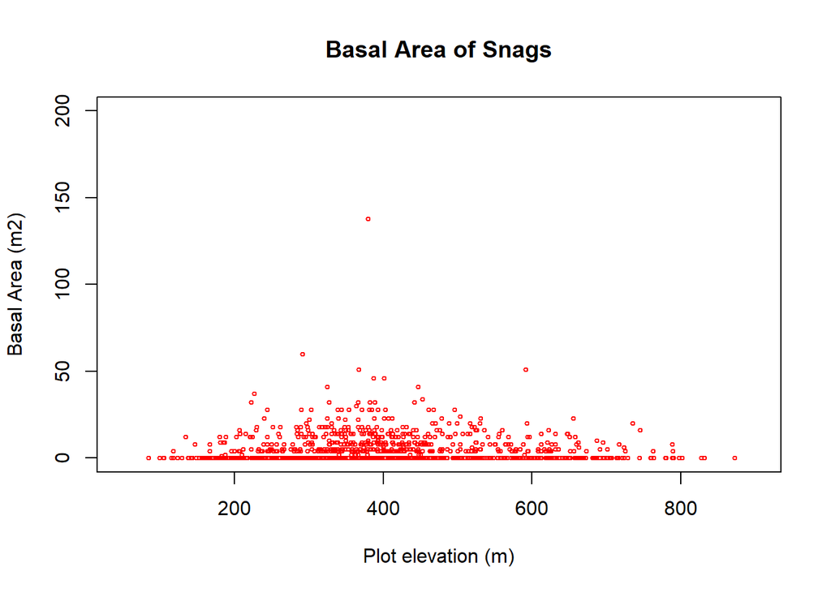

```r
# The following code will build a scatterplot with specific graphical arguments.

plot(x = dat_birds$elev, y = dat_birds$ba.snag,
     col = "Red",
     pch = 1,
     cex = .5,
     main = "Basal Area of Snags",
     xlab = "Plot elevation (m)",
     ylab = "Basal Area (m2)",
     xlim = c(50,900),
     ylim = c(0,200))
```

## Histogram

To plot a histogram in R use `hist()`. Some useful arguments that can be used within the plot call that can customize the visual graphics of your plot include the following:

‘breaks’ = Used to change how the histogram divides the intervals between values. R treats the ‘breaks’ argument as a suggestion. One way to provide the break points yourself is to use the breaks argument with a vector of values such as the following.

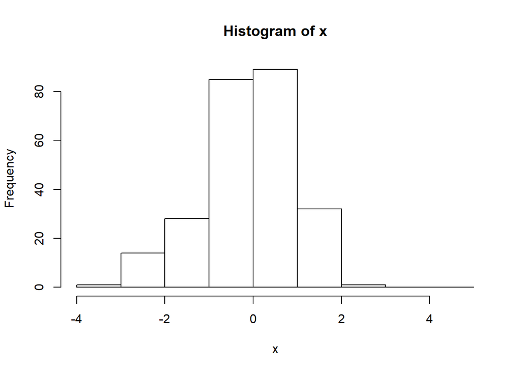

```r
x <- rnorm(250)
hist(x, breaks=c(-4,-3,-2,-1,0,1,2,3,4,5))
```

## Boxplots

To plot a Boxplot in R use `boxplot()`. Some useful arguments that can be used within the plot call that can customize the visual graphics of your plot include the following:

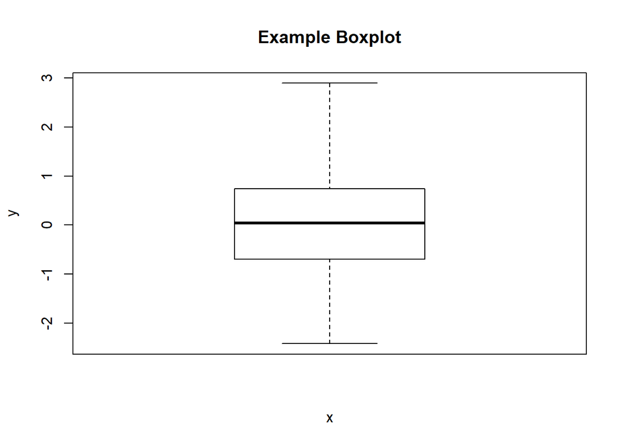

```r
# The following code will create a boxplot of a random normal distribution.

x <- rnorm(250)
boxplot(x, xlab = "x", ylab= "y", main = "Example Boxplot")
```

# Functions 4: Distribution Functions

The function `dnorm()` returns the value of the probability density function for a normal distribution given parameters for x, μ, and σ.

The function `pnorm()` returns the value of the distribution function for a normal distribution.

The function `qnorm()`returns the specified percentile (quantile) of a normal distribution.

```r
# What is the probability of an x value of 1 given a normal distribution with mean = 0 and standard deviation = 1?
dnorm(1, mean = 0, sd = 1)
```

```
## [1] 0.2419707
```

```r
# What percentage of values are less than 2 in a normal distribution with mean of 5 and standard deviation of 3?
pnorm(2, mean = 5, sd = 3)
```

```
## [1] 0.1586553
```

```r
# What is the Z-score of the 75th quantile of the normal distribution?
qnorm(.75, mean = 0, sd = 1)
```

```
## [1] 0.6744898
```

## Binomial Distribution

The binomial distribution is a discrete probability distribution. It describes the outcome of n independent trials in an experiment. Each trial is assumed to have only two outcomes, either success or failure. I can find the probability of having exactly x successes by random attempts using `dbinom()`.

```r
# What is the probability of 4 successes in random sample of size 12 and with each trial having 20% probability of success?

dbinom(4, size=12, prob=0.2)
```

```
## [1] 0.1328756
```

## pbinom

The function `pbinom()` returns the value of the cumulative density function (cdf) of the binomial distribution given a certain random variable q, number of trials (size) and probability of success on each trial (prob). This will return the probability of having x successes or less by random attempts.

```r
# What is the probability of 4 successes or less in random sample of size 12 and with each trial having 20% probability of success?

pbinom(4, size=12, prob=0.2)
```

```
## [1] 0.9274445
```

## Qbinom

The function `qbinom()` returns the value of the inverse cumulative density function (cdf) of the binomial distribution given a certain random variable q, number of trials (size) and probability of success on each trial (prob).

```r
# What is the 10th quantile of a binomial distribution with 10 trials and prob # of success on each trial = 0.4?

qbinom(.10, size=10, prob=.4)
```

```
## [1] 2
```

# Functions 5: Other Functions

## Subset

See previous description of subset function.

# Part 2: Data Anaylsis

## Delomys data summary

```r
dat_delomys = read.csv(here("data", "delomys.csv"))
summary(dat_delomys$body_mass)
```

```
##    Min. 1st Qu.  Median    Mean 3rd Qu.    Max.
##    5.00   35.00   43.00   44.06   54.00  105.00
```

```r
summary(dat_delomys$body_length)
```

```
##    Min. 1st Qu.  Median    Mean 3rd Qu.    Max.
##    49.0   106.0   116.0   114.7   124.0   265.0
```

```r
shapiro.test(dat_delomys$body_mass)
```

```
##
##  Shapiro-Wilk normality test
##
## data:  dat_delomys$body_mass
## W = 0.99506, p-value = 4.33e-05
```

```r
shapiro.test(dat_delomys$body_length)
```

```
##
##  Shapiro-Wilk normality test
##
## data:  dat_delomys$body_length
## W = 0.87609, p-value < 2.2e-16
```

## Scatterplot of body mass and body length

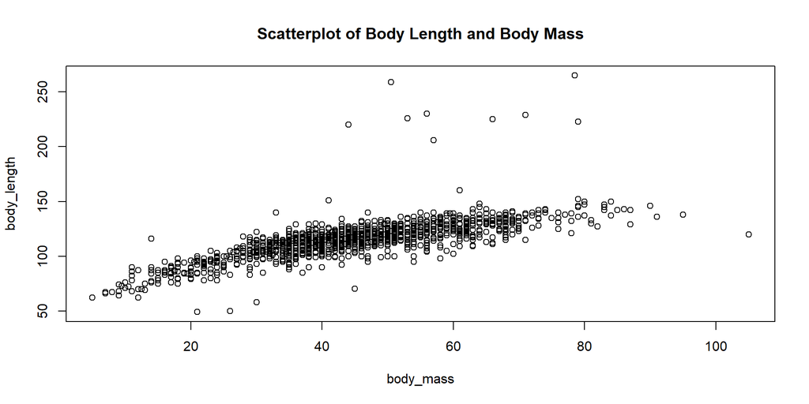

```r
require(here)
dat_delomys = read.csv(here("data", "delomys.csv"))

plot(body_length ~ body_mass, data = dat_delomys, main = "Scatterplot of Body Length and Body Mass")
```

## Histogram of Body Mass

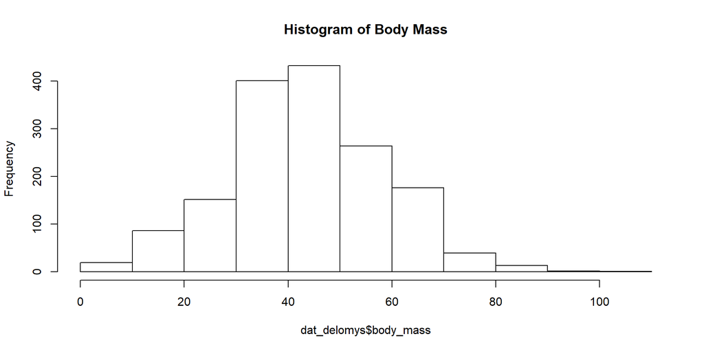

```r
hist(dat_delomys$body_mass, main = "Histogram of Body Mass")
```

## Histogram of body length

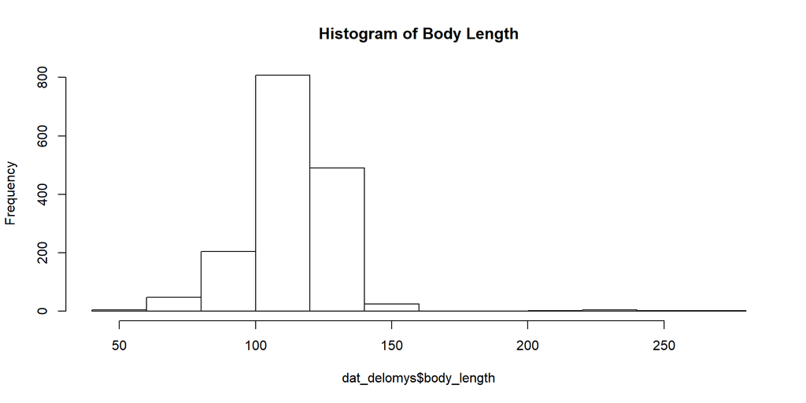

```r
hist(dat_delomys$body_length, main="Histogram of Body Length")
```

## Conditional boxplot of body mass, conditioned on species (column binomial)

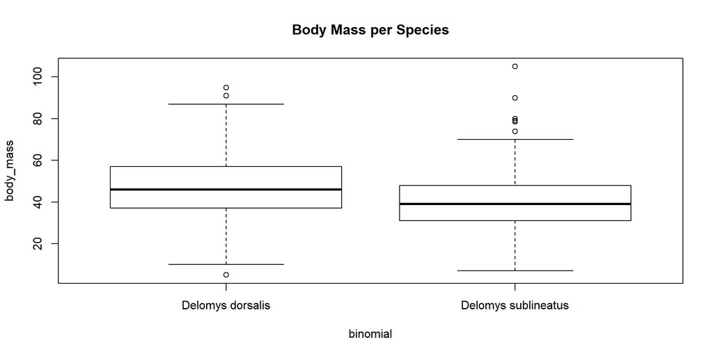

```r
boxplot(body_mass~binomial, data = dat_delomys, main = "Body Mass per Species")
```

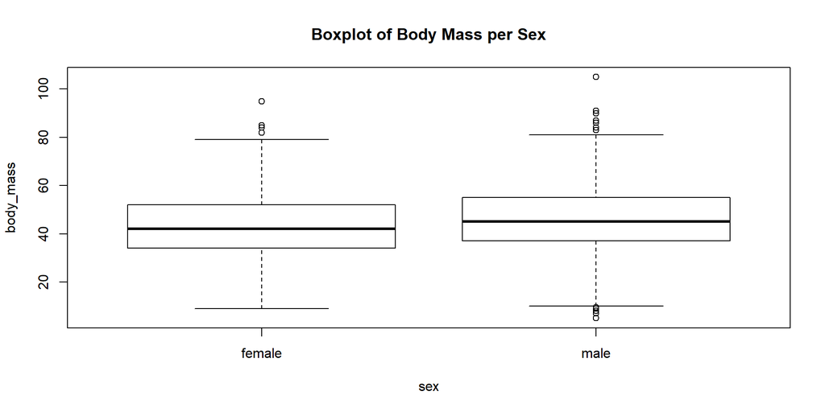

```r
boxplot(body_mass~sex, data = dat_delomys, main="Boxplot of Body Mass per Sex")
```

## conditional boxplot of body mass, conditioned on both species and sex

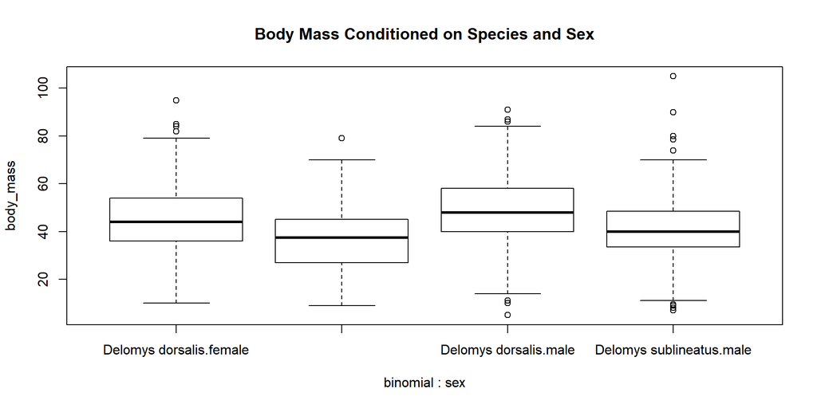

```r
boxplot(body_mass~binomial * sex, data = dat_delomys, main= "Body Mass Conditioned on Species and Sex")
```

## Analysis of Delomys data

1. Qualitatively describe the relationship between body mass and length:

Looking at the scatterplot of Body length and Body Mass, there appears to be a positive linear relationship between body mass and body length.

2. Qualitatively describe the shapes of the histograms. Do the data appear normally-distributed? Explain why or why not.

3. Using both the histograms and normality tests, do you think the (unconditioned) body masses and body length are normally-distributed?

4. Examine the conditional boxplots. Describe any graphical evidence you see for body mass differences based on species and/or sex.

Analyzing the conditional boxplots, it appears that the Delomys dorsalis species have a higher body mass than the Delomys sublineatus. I came to this conclusion because the mean body mass of both the male and female dorsalis species is higher then the corresponding sublineatus species.

Another observations could be made that the males of both species are slightly heavier then the females of each species. This can be determined visually by the boxplots since the mean values of the males are both higher than the corresponding female species.

# Model Building

## Model 1

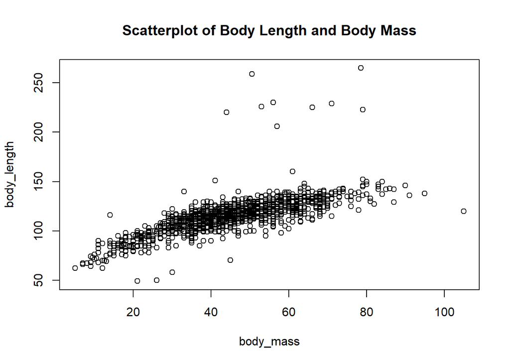

```r
plot(body_length ~ body_mass, data = dat_delomys, main = "Scatterplot of Body Length and Body Mass")
```

```r
fit_1 = lm(body_mass ~ body_length, data = dat_delomys)
fit_1
```

```
##
## Call:
## lm(formula = body_mass ~ body_length, data = dat_delomys)
##
## Coefficients:
## (Intercept)  body_length
##    -28.6931       0.6343
```

## Model 2

```r
fit_2= lm(body_mass ~ sex, data = dat_delomys)
anova(fit_2)
```

```
## Analysis of Variance Table
##
## Response: body_mass
##             Df Sum Sq Mean Sq F value    Pr(>F)
## sex          1   3062 3061.68  13.943 0.0001951 ***
## Residuals 1578 346507  219.59
## ---
## Signif. codes:  0 '***' 0.001 '**' 0.01 '*' 0.05 '.' 0.1 ' ' 1
```

## Model 3

```r
fit_3= lm(body_mass ~ binomial, data = dat_delomys)
anova(fit_3)
```

```
## Analysis of Variance Table
##
## Response: body_mass
##             Df Sum Sq Mean Sq F value    Pr(>F)
## binomial     1  21290 21289.7  102.08 < 2.2e-16 ***
## Residuals 1583 330164   208.6
## ---
## Signif. codes:  0 '***' 0.001 '**' 0.01 '*' 0.05 '.' 0.1 ' ' 1
```

## Model 4

```r
fit_4= lm(body_mass ~ sex + binomial, data = dat_delomys)
anova(fit_4)
```

```
## Analysis of Variance Table
##
## Response: body_mass
##             Df Sum Sq Mean Sq F value    Pr(>F)
## sex          1   3062  3061.7  14.958 0.0001144 ***
## binomial     1  23727 23727.1 115.923 < 2.2e-16 ***
## Residuals 1577 322780   204.7
## ---
## Signif. codes:  0 '***' 0.001 '**' 0.01 '*' 0.05 '.' 0.1 ' ' 1
```

## Model 5

```r
fit_5= lm(body_mass ~ sex * binomial, data = dat_delomys)
anova(fit_5)
```

```
## Analysis of Variance Table
##
## Response: body_mass
##                Df Sum Sq Mean Sq  F value    Pr(>F)
## sex             1   3062  3061.7  14.9489  0.000115 ***
## binomial        1  23727 23727.1 115.8500 < 2.2e-16 ***
## sex:binomial    1      1     0.8   0.0039  0.950442
## Residuals    1576 322779   204.8
## ---
## Signif. codes:  0 '***' 0.001 '**' 0.01 '*' 0.05 '.' 0.1 ' ' 1
```

## Model Diagnostics

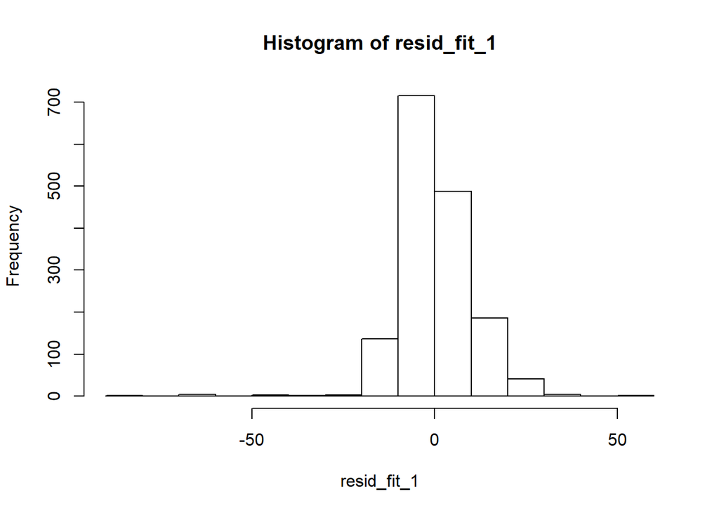

```r
resid_fit_1= residuals(fit_1)
hist(resid_fit_1)
```

```r
shapiro.test(resid_fit_1)
```

```
##
##  Shapiro-Wilk normality test
##
## data:  resid_fit_1
## W = 0.91563, p-value < 2.2e-16
```

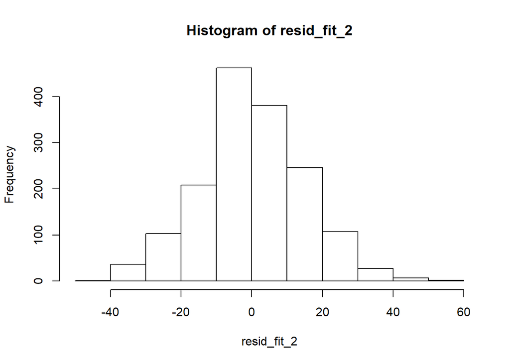

```r
resid_fit_2= residuals(fit_2)
hist(resid_fit_2)
```

```r
shapiro.test(resid_fit_2)
```

```
##
##  Shapiro-Wilk normality test
##
## data:  resid_fit_2
## W = 0.99563, p-value = 0.0001541
```

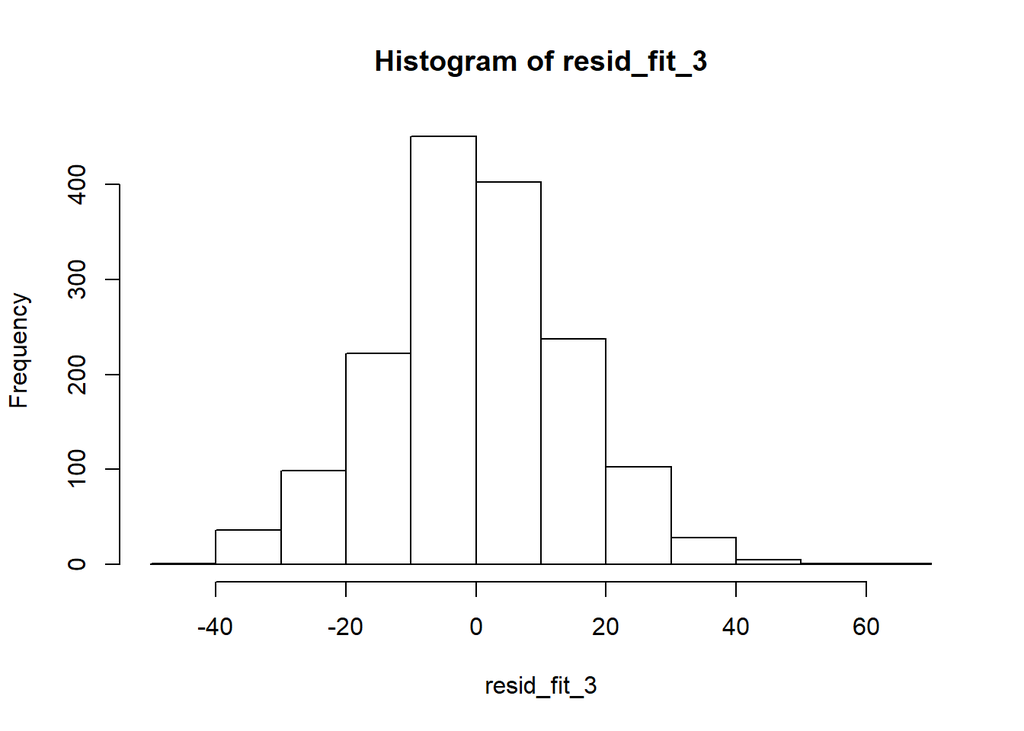

```r
resid_fit_3= residuals(fit_3)
hist(resid_fit_3)
```

```r
shapiro.test(resid_fit_3)
```

```
##
##  Shapiro-Wilk normality test
##
## data:  resid_fit_3
## W = 0.99535, p-value = 8.103e-05
```

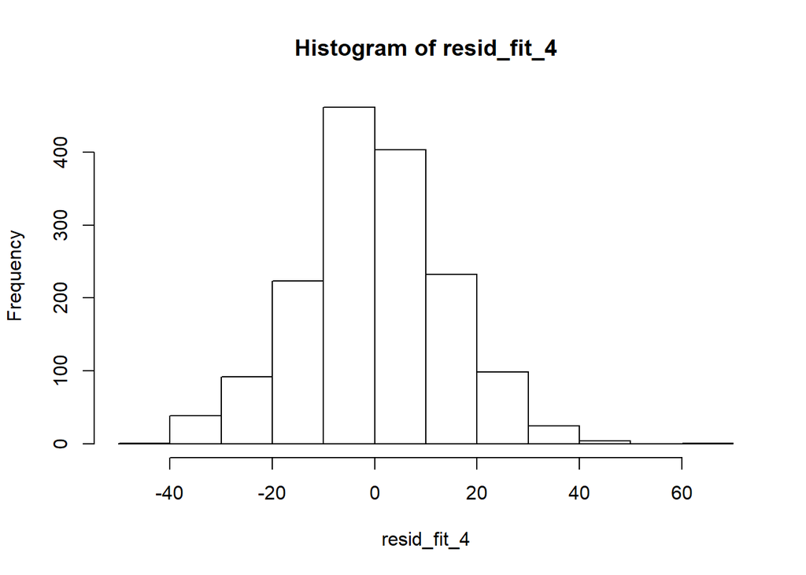

```r
resid_fit_4= residuals(fit_4)
hist(resid_fit_4)
```

```r
shapiro.test(resid_fit_4)
```

```
##
##  Shapiro-Wilk normality test
##
## data:  resid_fit_4
## W = 0.99525, p-value = 6.805e-05
```

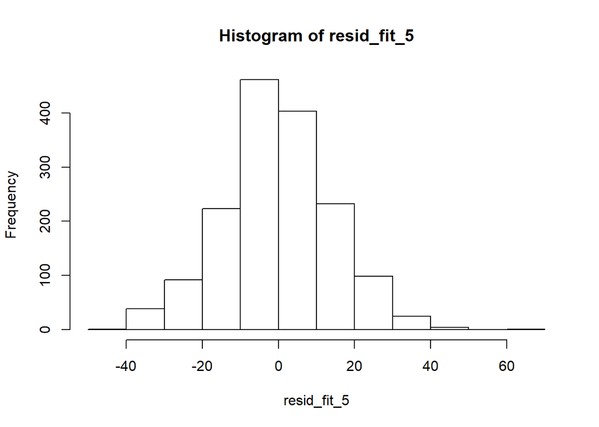

```r
resid_fit_5= residuals(fit_5)
hist(resid_fit_5)
```

```r
shapiro.test(resid_fit_5)
```

```
##
##  Shapiro-Wilk normality test
##
## data:  resid_fit_5
## W = 0.99526, p-value = 6.816e-05
```

## Model Interpretation

```r
# Model coefficient table for the mass/length relationship

knitr::kable(coef(summary(fit_1)))
```

|  | Estimate | Std. Error | t value | Pr(>\|t\|) |
| --- | --- | --- | --- | --- |
| (Intercept) | -28.6930718 | 1.6552332 | -17.33476 | 0 |
| body_length | 0.6343032 | 0.0142659 | 44.46298 | 0 |

1. What is the magnitude of the mass/length relationship?

Looking at the model coefficient table, for every unit increase of body_length the body_mass goes up by .6343. The intercept of the coefficient table is -28.69 which only makes sense scientifically when you consider that the species will never have a body_length of 0 (which would correspond with a -28.69 weight). In fact the minimum body length is 49 which would correspond with a 2.4g body mass according to the model coefficient table.

2. What is the expected body length of an animal that weighs 100g?

3. What is the expected body length of an animal that weighs 0g?

## Model Coefficient tables for body mass

```r
knitr::kable(coef(summary(fit_2)))
```

|  | Estimate | Std. Error | t value | Pr(>\|t\|) |
| --- | --- | --- | --- | --- |
| (Intercept) | 42.711465 | 0.5288929 | 80.756355 | 0.0000000 |
| sexmale | 2.784133 | 0.7456117 | 3.734024 | 0.0001951 |

```r
knitr::kable(coef(summary(fit_3)))
```

|  | Estimate | Std. Error | t value | Pr(>\|t\|) |
| --- | --- | --- | --- | --- |
| (Intercept) | 46.752427 | 0.4499933 | 103.89582 | 0 |
| binomialDelomys sublineatus | -7.683058 | 0.7604562 | -10.10322 | 0 |

```r
knitr::kable(coef(summary(fit_4)))
```

|  | Estimate | Std. Error | t value | Pr(>\|t\|) |
| --- | --- | --- | --- | --- |
| (Intercept) | 45.070355 | 0.5556429 | 81.113891 | 0e+00 |
| sexmale | 3.795395 | 0.7259609 | 5.228099 | 2e-07 |
| binomialDelomys sublineatus | -8.193492 | 0.7609985 | -10.766764 | 0e+00 |

```r
knitr::kable(coef(summary(fit_5)))
```

|  | Estimate | Std. Error | t value | Pr(>\|t\|) |
| --- | --- | --- | --- | --- |
| (Intercept) | 45.0554562 | 0.6052973 | 74.4352459 | 0.0000000 |
| sexmale | 3.8280908 | 0.8966667 | 4.2692460 | 0.0000208 |
| binomialDelomys sublineatus | -8.1417394 | 1.1281046 | -7.2171847 | 0.0000000 |
| sexmale:binomialDelomys sublineatus | -0.0950187 | 1.5285856 | -0.0621612 | 0.9504424 |

1. What is the base level for sex?

The base level for sex would be females

2. What is the base level for binomial?

The base level for binomial would be Delomys dorsalis.

3. Which sex is heavier?

The male sex is heavier since the coefficient estimate is positive.

4. Which species is heavier?

Delomys dorsalis is heavier since sublineatus has a negative coefficient estimate.

## Anova tables of the body mass

```r
knitr::kable(anova(fit_1))
```

|  | Df | Sum Sq | Mean Sq | F value | Pr(>F) |
| --- | --- | --- | --- | --- | --- |
| body_length | 1 | 195173.6 | 195173.60329 | 1976.957 | 0 |
| Residuals | 1583 | 156280.5 | 98.72427 | NA | NA |

```r
knitr::kable(anova(fit_2))
```

|  | Df | Sum Sq | Mean Sq | F value | Pr(>F) |
| --- | --- | --- | --- | --- | --- |
| sex | 1 | 3061.678 | 3061.6779 | 13.94294 | 0.0001951 |
| Residuals | 1578 | 346507.131 | 219.5863 | NA | NA |

```r
knitr::kable(anova(fit_3))
```

|  | Df | Sum Sq | Mean Sq | F value | Pr(>F) |
| --- | --- | --- | --- | --- | --- |
| binomial | 1 | 21289.68 | 21289.6805 | 102.0751 | 0 |
| Residuals | 1583 | 330164.45 | 208.5688 | NA | NA |

```r
knitr::kable(anova(fit_4))
```

|  | Df | Sum Sq | Mean Sq | F value | Pr(>F) |
| --- | --- | --- | --- | --- | --- |
| sex | 1 | 3061.678 | 3061.6779 | 14.95838 | 0.0001144 |
| binomial | 1 | 23727.134 | 23727.1342 | 115.92320 | 0.0000000 |
| Residuals | 1577 | 322779.997 | 204.6798 | NA | NA |

```r
knitr::kable(anova(fit_5))
```

|  | Df | Sum Sq | Mean Sq | F value | Pr(>F) |
| --- | --- | --- | --- | --- | --- |
| sex | 1 | 3.061678e+03 | 3.061678e+03 | 14.948932 | 0.0001150 |
| binomial | 1 | 2.372713e+04 | 2.372713e+04 | 115.849977 | 0.0000000 |
| sex:binomial | 1 | 7.913846e-01 | 7.913846e-01 | 0.003864 | 0.9504424 |
| Residuals | 1576 | 3.227792e+05 | 2.048091e+02 | NA | NA |

1. Are sex and species significant predictors for body mass?

Yes, both sex and species are significant predictors of body mass, since they have very low p-values.

2. Is there a significant interaction?

Since the two way anova table of fit_5 has a high p-value above the alpha level this indicates that there is not a significant interation between these two variables.

3. Does the significance (as measured by p-value) of either of the main effects (sex and species) differ much between the single-predictor models, the additive model, and the interactive model?

The sex or species effect do not differ significantly in any of the models, since the p-values are consistently very low.

## Model Comparison: Body Mass

```r
AIC(fit_1)
```

```
## [1] 11780.88
```

```r
AIC(fit_2)
```

```
## [1] 13006.8
```

```r
AIC(fit_3)
```

```
## [1] 12966.36
```

```r
AIC(fit_4)
```

```
## [1] 12896.73
```

```r
AIC(fit_5)
```

```
## [1] 12898.72
```

1. Which two models have the lowest AIC?

The models with the lowest AIC are fit_1 (11780.88) and fit_4 (12896.73).

2. Which of the two models with lowest AIC scores would you select?

I would choose model 1 based off of these model comparisons. This linear regression model is less complex then the other models and therefore will be simpler to interpret. It also has the lowest AIC which means it has the best fit.